# BIOL7263-03 Project

Laci Cartmell

##### Quick Note: This Repo is used in conjuctiong with a project for BIOL7263-03: Genome Biology

## Background

The swallow bug, C. vicarius, primarily parasitize cliff swallows which are colonial and migratory birds. Swallow bugs rely on these birds for passive dispersal between colonies, as they lack wings and colonies are typically separated by distances ranging from 1 to 10 km. Cliff swallows frequently move between colonies, especially during the beginning and end of the breeding season. During this time, swallow bugs engage in a dispersal behavior by clustering at the edge of the nests and jumping onto visting birds.

Previous research using mtDNA and microsatellites has shown that the genetic diversity of swallow bugs is negatively correlated with distance from ancestral cliffs (Moore, 2016). The negative association found is likely due to the expansion of cliff swallows eastward, facilitated by the increase in anthropogenic structures. However, it’s unclear how frequently swallow bugs disperse between colonies and whether geographic distance could be a limiting factor.

One method for measuring dispersal is to examine the genetic similarity between colonies. Fst, a measure of genetic differentiation, can indicate levels of isolation; greater genetic similarity suggests more gene flow, or dispersal. Longer distances may reduce the likelihood of successful dispersal, and therefore, there should be less gene flow between colonies that are farther apart.

Isolation by distance (IBD) is a method to analyze if the genetic differences between the colonies increase with geographic distance.

For this project, the goal is to test whether isolation by distance exists for swallow bugs. My hypothesis is that swallow bugs will not exhibit isolation by distance, as the frequent movement of cliff swallows between colonies likely facilitates gene flow and dispersal

## Sequence Generation

Ten swallow bugs were sequenced from 23 and 14 cliff swallow colonies from 2014 and 2021, respectively. The raw sequencing files were generated with a double-digest restriction-associated sequencing (ddRAD-seq) library preparation method based on Peterson et al. (2012). Single-read sequences were generated using Illumina HiSeq 4000. There are 8 raw sequence files that are stored on a google drive folder (email for access)

# Post-sequencing Tasks

- Quality control with FastQC and MultiQC
- Trimming and Demultilexing - process_radtags in Stacks
- Alignment of reads - Integrated method with Stacks
- Post-Alignment
  - check alignment quality
  - calculate Fst & geographic distance

## Quality Control w/FastQC & MultiQC

Quality checks were done on the raw & demultiplexed files using FastQC. Visualizing hundreds of files can be daunting, which is where MultiQC comes in. It summarizes the statistics from FastQC in an easy to read format. If problem sequences exist, then can be identified and their FastQC files looked at more closely. The results contains summary figures using MultiQC on the browswer.

Files:

- [fastqc output files](https://github.com/laci-cartmell/cimex.vicarius.ddRAD-seq/tree/main/fastqc)
- [fastqc.sbatch](https://github.com/laci-cartmell/cimex.vicarius.ddRAD-seq/blob/main/scripts/fastqcloop.sbatch)

## Trimming and Demultiplexing

The raw Illumina files need to be demultiplexed so that each individual swallow bug will have its own .fq.gz file. The module process_radtags in STACKS demultiplexes the files based on unique barcode sequences. The barcodes are in the required file directory. It is also able to ‘clean’ reads. The reads must pass a phred quality score of 30 with a sliding window.

The process_radtags also generates values such as reads and percentage of total reads kept after cleaning. These were looked at in excel and all samples less than 100k samples were discarded.

Samples were separated into 2014 and 2021 for all future scripts - so most were run twice, once for 2014 & 2021.

Files:

- [radtag_0301](https://github.com/laci-cartmell/cimex.vicarius.ddRAD-seq/blob/main/scripts/radtags_2203-01.sbatch)
- [radtag_0302](https://github.com/laci-cartmell/cimex.vicarius.ddRAD-seq/blob/main/scripts/radtags_2203-02.sbatch)
- [radtag_0308](https://github.com/laci-cartmell/cimex.vicarius.ddRAD-seq/blob/main/scripts/radtags_2203-08.sbatch)
- [radtag_0901](https://github.com/laci-cartmell/cimex.vicarius.ddRAD-seq/blob/main/scripts/radtags_2209-01.sbatch)
- [radtag_0902](https://github.com/laci-cartmell/cimex.vicarius.ddRAD-seq/blob/main/scripts/radtags_2209-02.sbatch)
- [radtag_1001](https://github.com/laci-cartmell/cimex.vicarius.ddRAD-seq/blob/main/scripts/radtags_2210-01.sbatch)
- [radtag_1101](https://github.com/laci-cartmell/cimex.vicarius.ddRAD-seq/blob/main/scripts/radtags_2211-01.sbatch)
- [radtags_1102](https://github.com/laci-cartmell/cimex.vicarius.ddRAD-seq/blob/main/scripts/radtags_2211-02.sbatch)

## Alignment of reads - Integrated method

An integrated alignment is neat becuase it utilizes both de novo and reference alignments. The short-reads are first assembled into loci for each individual, then the loci matched to high quality samples are used to build a catalog that each sample is matched too. Further steps sorts by locus and phase SNPs into genotypes. However, this is the basis of the de novo assembly - the catalog of high quality samples act as the main ‘reference’ on which to map an individual sequences. ‘Stacks’ of loci occur where multiple samples contain the same sequence. The number and depth of these stacks are controlled by parameters that are set-up during optimization.

scripts for de novo:

- [ustacks_array_2014](https://github.com/laci-cartmell/cimex.vicarius.ddRAD-seq/blob/main/scripts/ustacks_array_2.sh)
- [ustacks_array_2021](https://github.com/laci-cartmell/cimex.vicarius.ddRAD-seq/blob/main/scripts/ustacks_array_2021_2.sh)
- [cstacks](https://github.com/laci-cartmell/cimex.vicarius.ddRAD-seq/blob/main/scripts/cstacks.sbatch)
- [sstacks](https://github.com/laci-cartmell/cimex.vicarius.ddRAD-seq/blob/main/scripts/sstacks.sbatch)
- [bwa2bam](https://github.com/laci-cartmell/cimex.vicarius.ddRAD-seq/blob/main/scripts/bwamem.sbatch)
- [tsv2bam](https://github.com/laci-cartmell/cimex.vicarius.ddRAD-seq/blob/main/scripts/sstacks.sbatch)
- [gstacks](https://github.com/laci-cartmell/cimex.vicarius.ddRAD-seq/blob/main/scripts/gstacks.sbatch)

The next step for an integrated alignment is to align the consensus sequences to a reference genome. The genome doesn’t need to be from the same species, but the more closely related the better. Two closely related genomes were available. I chose to align to C.lectularius as more of my sequences mappped to it than the available C. hempiterus genome.

I used BWA as my alignment tool to align the loci to the reference genome. Then used samtools to convert to a BAM file. At this time, I also generated summary statistics with flagstat

- [map_stats_2014](https://github.com/laci-cartmell/cimex.vicarius.ddRAD-seq/blob/main/mappingstats14.txt)
- [map_stats_2021](https://github.com/laci-cartmell/cimex.vicarius.ddRAD-seq/blob/main/mappingstats21.txt)

I used another module from stacks - stacks-integrate-alignments. It takes the coordinates from the BAM file and inserts them into the catalog.

The final step is to use populations module to generate general statistics and output files for use in R. A genepop file was exported from Stacks.

scripts for integration:

- [integrated-ailgnment](https://github.com/laci-cartmell/cimex.vicarius.ddRAD-seq/blob/main/scripts/integrate.sbatch)
- [populations](https://github.com/laci-cartmell/cimex.vicarius.ddRAD-seq/blob/main/scripts/populations.sbatch)

## From the populations in stacks - it generates a genepop file

Genepop Files:

- [2014 genepop](https://github.com/laci-cartmell/cimex.vicarius.ddRAD-seq/blob/main/RequiredFiles/populations.snps14.genepop)
- [2021 genepop](https://github.com/laci-cartmell/cimex.vicarius.ddRAD-seq/blob/main/RequiredFiles/populations.snps21.genepop)

Genepop files are a common file type for population statistics software such as Arelquin. However, I decided to work with Adgenet for generating population statistics as it is also frequenctly used in R but can also store population metadata. The genind were used for general pop stats, but the hierfstat package in R was ultimately used to generate Fst.

The population statistic, Fst, can be used as a measure of genetic distance. It was calculated based on the Wier and Cockerham method.

2014

- [Fst](https://github.com/laci-cartmell/cimex.vicarius.ddRAD-seq/blob/main/Output_R/pairwise.WCfstZ.txt)
- [Fst_UpperLimit](https://github.com/laci-cartmell/cimex.vicarius.ddRAD-seq/blob/main/Output_R/boot.fst.ul.txt)
- [Fst_LowerLimit](https://github.com/laci-cartmell/cimex.vicarius.ddRAD-seq/blob/main/Output_R/boot.fst.ll.txt)

2021

- [Fst](https://github.com/laci-cartmell/cimex.vicarius.ddRAD-seq/blob/main/Output_R/pairwise.WCfstZ.21.txt)
- [Fst_UpperLimit](https://github.com/laci-cartmell/cimex.vicarius.ddRAD-seq/blob/main/Output_R/boot.fst.ul21.txt)
- [Fst_LowerLimit](https://github.com/laci-cartmell/cimex.vicarius.ddRAD-seq/blob/main/Output_R/boot.fst.ll21.txt)

The geographic distance was calculated using coordinates for each colony location. The distance between each colony was calculated using Geosphere (distance based on WGS1984 geodesic).Then a pairwise distance matrix was calculated.

[geo_distance R script](https://github.com/laci-cartmell/cimex.vicarius.ddRAD-seq/blob/main/Output_R/boot.fst.ll21.txt)

[fst_calculation R script](https://github.com/laci-cartmell/cimex.vicarius.ddRAD-seq/blob/main/scripts/FST_calculation.R)

The pairwise matrices were then used for calculating the Mantel statistics using the package Vegan.

Script: [mantel_test R script](https://github.com/laci-cartmell/cimex.vicarius.ddRAD-seq/blob/main/scripts/manteltest.R)

## The Results

The pairwise Fst were low, and most were not significantly different from other colonies.

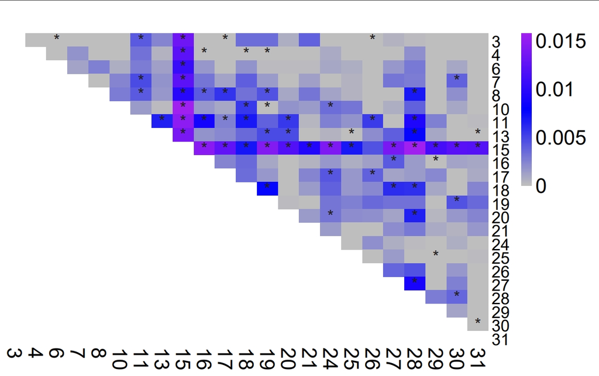

Pairwise Heatmap of Fst for all sampled colonies in 2014

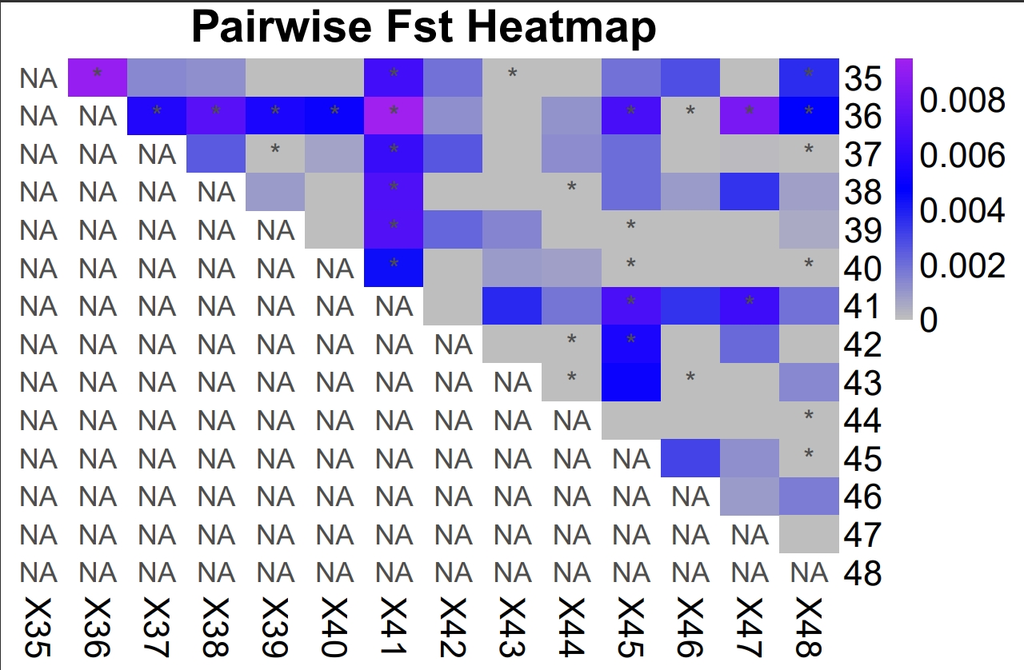

Pairwise Heatmap of Fst for all sampled colonies in 2021

The mantel tests were non-significant for 2014 and 2021. The Mantel r-value was 0.0656 for 2014 and -0.0159 for 2021.

[figure not shown]

The genetic distance (Fst) against Geographic distance for 2014. The regression line is in red.

[figure not shown]

## Conclusion

The small pairwise Fst values indicate that swallow bugs have high gene flow between cliff swallow colonies. This lack of strong genetic differentiation suggest that the population is panmictic with frequent dispersal. There was no significant correlation between genetic isolation and geographic distance for either 2014 or 2021 groups. This lack of isolation by distance (IBD) supports the hypothesis that frequent dispersal, facilitated by cliff swallows’ movements between colonies, plays a key role in maintaining gene flow.

Swallow bugs appear to disperse between colonies with no effect by distance, which aligns with the expectation that the movement of cliff swallows-especially during the ends of the breeding season-promotes passive dispersal. The dispersal behavior of the swallow bugs enables them to effectively move between colonies, further explaining the absence of IBD.